# Pourquoi programmer en Python ?

Python pour les SHS

Émilien Schultz

## Objectifs du module

- Avoir une vue générale de ce qu’est la programmation
- Comprendre la place du langage Python
- Identifier des exemples d’usages
- Mener une discussion transversale sur les pratiques

## Quelques questions pour commencer

> Pourquoi programmer en 2026 en Python en sciences sociales ?
1. Pourquoi programmer (en recherche) ?
2. Pourquoi Python ?
3. Et l’IA dans tout ça ?

# Pourquoi programmer ?

*“Certains disent « Il faut coder », d’autres rétorquent « Il faut décoder »”* (Cardon, 2019)

## Programmer ?

Utiliser des instructions (code/script) dans un langage (formalisé) pour faire exécuter des actions à un ordinateur.

[figure not shown]

## La science est numérique

- Numérisation comme point de passage obligé
- Abondance de données à actionner
- Nouvelles méthodes & terrains en SHS
- Favoriser la reproductibilité pour la science ouverte

## Central pour la reproductibilité

De plus en plus important

[figure not shown]

Juliette Taka, & Nicolas M. Thiéry. (2018). Publishing reproducible logbooks explainer comic strip. Zenodo. https://doi.org/10.5281/zenodo.4421040

## La programmation en recherche

Transversale aux usages numériques

- Formaliser et automatiser son traitement
- Utiliser les ressources que d’autres développent
- Dépasser ce qui est prévu dans les logiciels
- Construire des outils pour soi et les autres

## Des différences disciplinaires

[figure not shown]

Nous ne faisons pas tous la même chose

- diversité de méthodes
- diversité des données
- diversité de cultures

> [“*De la poussière à la lumière bleue*” de Caroline Muller et Frédéric Clavert, Signata, 2021](https://journals.openedition.org/signata/3136)

## De multiples usages en archéologie

| Exemple | Méthode | Réf. |
| --- | --- | --- |
| Rouleaux d’Herculanum | CT + deep learning (détection d’encre) | [CNN, 2026](https://keyt.com/news/national-world/cnn-other/2026/06/26/papyrus-scroll-burnt-to-a-crisp-during-vesuvius-eruption-deciphered-with-help-of-ai/) |
| Inscriptions latines (Aeneas) | Réseau neuronal génératif | [DeepMind, 2025](https://deepmind.google/discover/blog/aeneas-transforms-how-historians-connect-the-past/) |
| Géoglyphes de Nazca | Vision par ordinateur (drones) | [Sakai et al., 2024](https://archaeology.org/news/2024/09/27/more-than-300-geoglyphs-discovered-in-peru/) |
| Désert d’Arabie | Segmentation (U-Net…) | [HeritageDaily, 2026](https://www.heritagedaily.com/2026/04/ai-tools-speed-up-search-for-ancient-desert-structures-in-arabia/157773) |
| Anatolie, âge du Bronze | Modèle multi-agents | [Koçaklı, 2025](https://research.itu.edu.tr/en/publications/exploring-the-evolution-of-socio-ecological-systems-through-agent/) |
| Ancêtres archaïques (TRACE) | Génomique computationnelle | [Science, 2026](https://www.labmanager.com/new-computational-method-traces-dna-from-unknown-human-ancestors-35768) |

## Concrètement, pluralité d’usages

| Niveau | Usages | Exemples |
| --- | --- | --- |
| **Mimétisme** | Suivre un tutoriel, lancer un code existant | Leçons de la revue [Programming Historian](https://programminghistorian.org/) |
| **Scripts** | Manipuler et transformer des données, scripter dans un logiciel | Découper un fichier trop volumineux, mettre en forme un corpus pour Iramuteq, scripts QGIS / OpenRefine / Grist |
| **Statistiques** | Graphiques, statistiques, exploration de textes, calcul parallèle | Notebook d’exploration d’une enquête en ligne, TAL pour l’analyse thématique |
| **Automatisation** | Collectes API, surveillance, workflows, déploiement web | OCR Gallica, suivi des modifications d’un site, chaîne collecte → analyse → résultats |
| **IA** | Requêter les API, manipuler et entraîner des modèles | API OpenAI, modèles HuggingFace, détection d’entités nommées sur mesure, fine-tuning de LLM |
| **Instrumentation** | Généraliser son code, publier, déployer | Fonction réexécutable, publication d’une bibliothèque, service en ligne |
| **Logiciel** | Développer des outils génériques | Ipysigma, module QGIS, interface pour mettre un modèle en service |

## Réussir à programmer : agencer un ensemble d’éléments

- Matériel (stockage, calcul, périphériques)
- Logiciel (OS, IDE, etc.)
- Données (informations, formats)
- Langage (instructions, grammaire)
- Écriture en algorithme (optimisation, …)

## Un apprentissage multiniveaux

*La side quest de la programmation*

- Se familiariser avec les environnements informatiques
  - Ligne de commande, …
- Penser la structure des données et leur diversité
  - Format de fichier : csv ou xls ?
- Penser la matérialité des pratiques
  - Stockage mémoire vive, cloud ou disque dur ?

## Interdépendant de la recherche

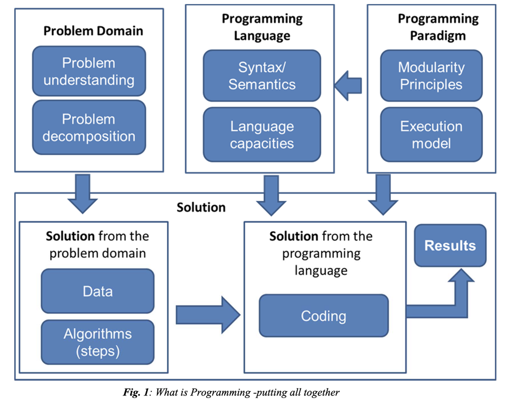

[What is Programming? Putting all Together](https://ieeexplore.ieee.org/document/8645956)

## Les langages de programmation

Abstractions permettant d’écrire des instructions

- Séparer le matériel (spécifique, code machine) des opérations (génériques, code source)
  - Compilation/interprétation
- Des langages différents (plus ou moins abstraits)
- Des opérations partagées par tous les langages (opérations mathématiques)

## 50 nuances de programmation

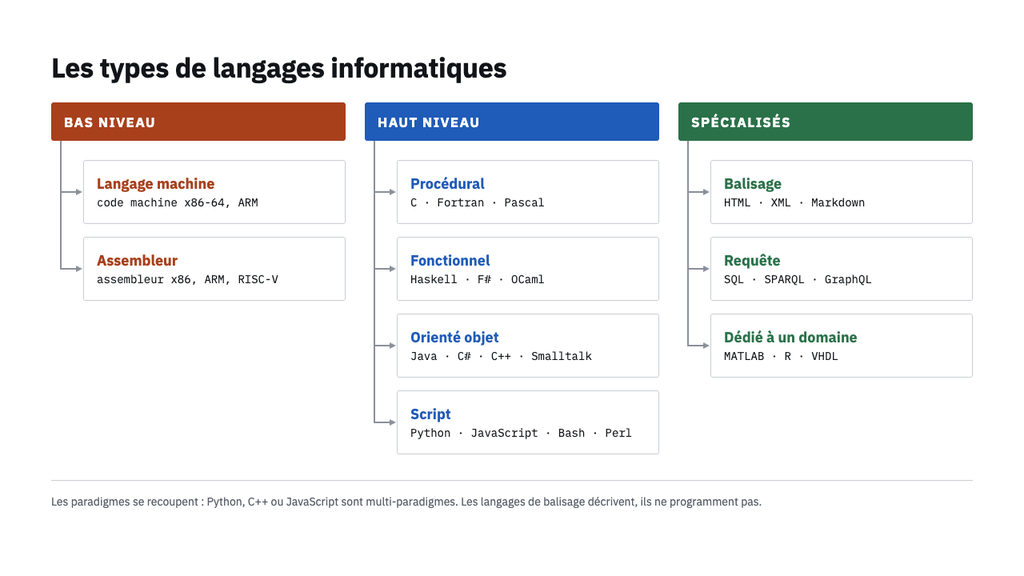

## La programmation scientifique

- **Script** : réaliser des petites tâches spécifiques
- **Interactivité** : tester et expérimenter
- **Spécificité** : des outils spécifiques
- **Temporaire** : évolution permanente

« in contrast to software engineering, there is no externally specified goal or design target. Instead, the user explores and discovers their goal as they gain understanding from iteratively executing the code and thinking about the results and their data. » (Granger et Perez, 2021)

## Et amateurisme !

[figure not shown]

## Non exclusif avec les logiciels

[figure not shown]

*(de la programmation au sein des logiciels : QGIS, Grist, etc.)*

# Pourquoi Python ?

## Python c’est ça :

Filtrer un tableau (en csv) qui contient un mot (python)

```python
import pandas as pd
df = pd.read_csv("fichier_conferences.csv")
sub = df[df["titre"].str.contains("python")]
sub.to_csv("conferences_python.csv")
```

## Et Python c’est aussi ça :

Lancer une prédiction avec un LLM dans un logiciel

```python
def __call__(self) -> ReturnTaskPredictModel:
    """
    Main process to predict
    """
    if self.df is None:
        raise ValueError("Dataframe is required for prediction")
    tokenizer, model, max_length = self.__load_model()
    gpu = False
    if torch.cuda.is_available():
        print("GPU is available")
        torch.cuda.empty_cache()
        gpu = True
        model.cuda()
    try:
        predictions = []
        for i in range(0, self.df.shape[0], self.batch):
            print("Next chunck prediction")
            self.__listen_stop_event()
            chunk = tokenizer(
                list(self.df[self.col_text][i : i + self.batch]),
                padding=True,
                truncation=True,
                return_tensors="pt",
                max_length=max_length,
            )
            if gpu:
                chunk = chunk.to("cuda")
```

## Parce que : tout est possible

[figure not shown]

## Parce que : langage de haut niveau

[figure not shown]

## Parce que : data science

[figure not shown]

## Et plus généralement

- libre et interopérable
- polyvalent
- pédagogique par design
- enseigné de plus en plus tôt
- le plus utilisé en traitement des données
  - [Sondage Stack Overflow](https://survey.stackoverflow.co/2023/#technology-most-popular-technologies) ; [TIOBE index](https://www.tiobe.com/tiobe-index/) ; [GitHub](https://github.blog/news-insights/octoverse/octoverse-2024/)

## Une lingua franca

[figure not shown]

## Le produit d’une histoire

[figure not shown]

[The Origins of Python, Lambert Meertens, 2022](https://inference-review.com/article/the-origins-of-python)

## Traversé par une philosophie

```python
import this
```

Beautiful is better than ugly.

Explicit is better than implicit.

Simple is better than complex.

Complex is better than complicated.

Flat is better than nested.

Sparse is better than dense.

Readability counts.

Special cases aren’t special enough to break the rules.

Although practicality beats purity.

…

## En perpétuelle évolution

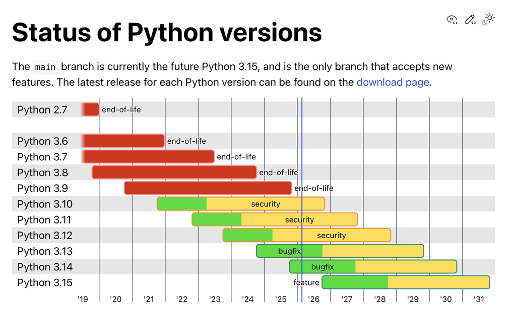

Release annuelle

## Ancré dans la pratique scientifique

[figure not shown]

## Python : un langage & un écosystème

[figure not shown]

# Avant de se lancer

## Tous.tes programmeurs.euses ?

Non

- Mais une culture numérique devient indispensable
  - Au moins pour choisir
- Et cela facilite les échanges pour les collaborations
  - Avec des humains
  - Et avec les outils génératifs…

## Différents profils de programmation

Des apprentissages différenciés

[figure not shown]

## Une question récurrente

Quel langage choisir ?

[figure not shown]

[figure not shown]

## Python ou R ? Des points communs

[figure not shown]

- Python et R ++ pour traitement de données
- Python ++ interface informatique/privé
- R ++ pour statistiques
- Python ++ pour ML
- Python ++ production

Python = *“the best second language”*

## Une évolution en cours

[figure not shown]

## Plus généralement : Python, Julia, R ?

- Des langages qui évoluent
  - Par exemple les *f-string*, l’asynchrone, …
- Abstraction progressive
  - Cas du projet Jupyter
- Le bouleversement du génératif (on en parlera)

Pas de “meilleur langage” dans l’absolu

## L’important est d’avoir un outil

[figure not shown]

[Python is not a great language for data science](https://blog.genesmindsmachines.com/p/python-is-not-a-great-language-for)

## GenIA : un bouleversement des pratiques ?

[figure not shown]

## Un climat un peu anxieux

[figure not shown]

## Situation actuelle

- Modèles frontières puissants
- Intégration dans les outils de développement
- Montée des usages agentiques
- Des chaînes de délégation de plus en plus longues

## Plus généralement

- Position **pro-adoption** : inéluctabilité ; usages ciblés/augmentation ; déplacement des pratiques vers la supervision et la conception fonctionnelle
- Position **sceptique** : déqualification du travail ; perte des expertises ; dépendance à des acteurs hégémoniques US…
- Questions ouvertes :
  - Conséquences sur l’apprentissage
  - Conséquences sur la déqualification
  - Conséquences sur le bien commun du code

## Ma position

Les outils sont puissants et permettent à la fois l’accélération et l’autonomie, mais avec un risque de perte de maîtrise

- Le code est plus lu qu’écrit
  - Importance de rendre le code habitable
- Le code est lié à la réflexion
  - Programmation lettrée
- L’architecture générale est importante

## Un débat en cours …

[figure not shown]

[figure not shown]

## Réfléchir à ce qu’on délègue

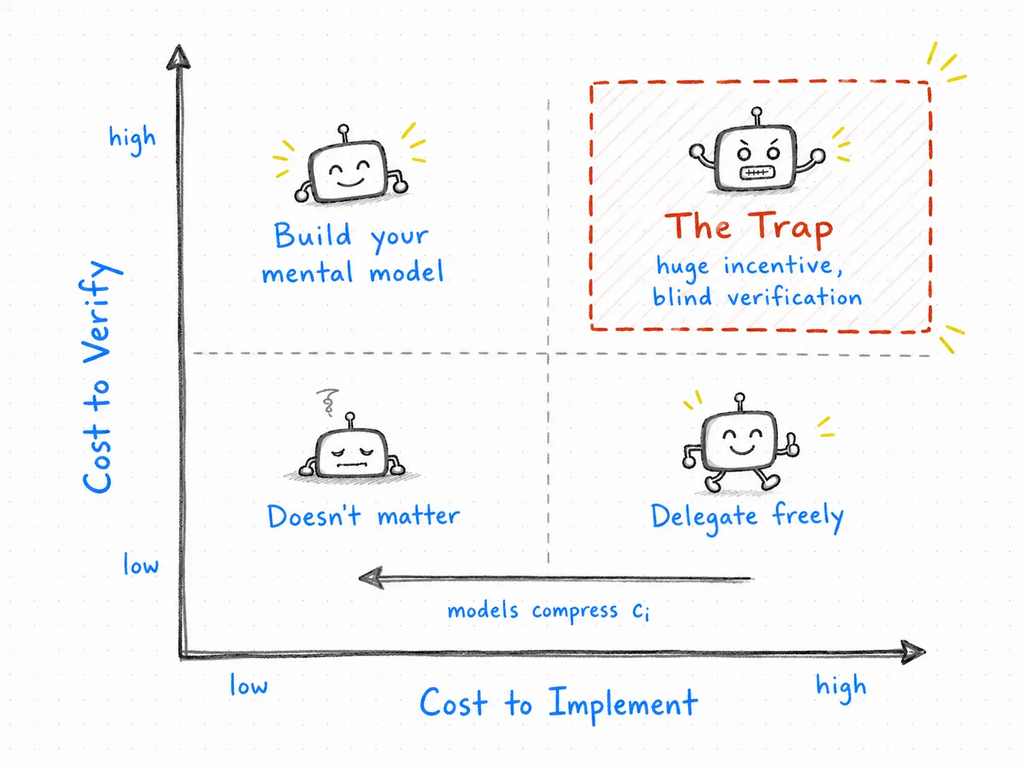

https://paulgp.substack.com/p/will-ai-replace-rasprofessorseconomists

## Et savoir ce qu’on perd au change

[figure not shown]

## *Caveat* avant de commencer

- Programmer ≠ tout savoir
  - De nombreux domaines spécialisés (ML, NLP, Réseaux, …)
- Pas une baguette magique
- Courbe d’apprentissage potentiellement longue (mais…)
- Importance des ressources locales (collègues)

[figure not shown]

## Facile mais …

[figure not shown]

## Programmer ≠ data science

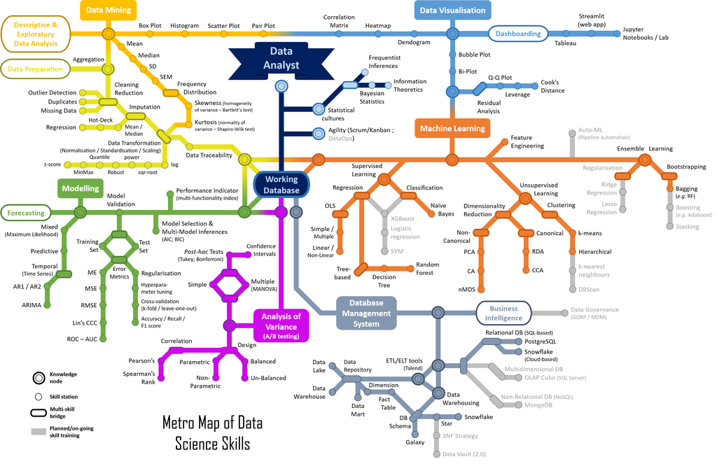

## Nous ne sommes pas égaux

Pour s’y mettre

- Des trajectoires différentes
- +/- familiarité à la programmation

Deux grandes philosophies :

- CLI : la ligne de commande (Linux notamment)
- GUI : les interfaces graphiques (WYSIWYG)

## Progresser ?

Pas en une fois

- Développer l’espace des possibles
  - Bases du langage et philosophie
  - Des exemples de ce qu’il est possible de faire
- Identifier un usage pertinent pour soi
  - Construire de manière itérative sa pratique
- Améliorer sa pratique
  - Ajouter les bonnes pratiques de code / partage
  - Renforcer les aspects “théoriques” et “esthétiques”

## Valoriser les petites victoires

[figure not shown]

Possibilité d’un vrai plaisir

## Le pragmatisme d’abord

[figure not shown]

## À retenir

- **Programmer**, c’est formaliser, automatiser et rendre reproductible son traitement, en complément des logiciels
- **Une pluralité d’usages**, du script ponctuel à l’outil partagé : pas besoin de tout savoir
- **Python** : libre, polyvalent, lisible, porté par un écosystème scientifique et une communauté
- **Pas de « meilleur langage »** dans l’absolu : l’important est d’avoir un outil
- **IA générative** : un accélérateur, à condition de choisir ce qu’on délègue et de pouvoir le vérifier
- **Progresser pas à pas**, à partir d’un usage pertinent pour soi

## Ressources

- [Online : Python pour la data science, Lino Galiana](https://pythonds.linogaliana.fr/)
- [Online : Python for cultural studies, Melanie Walsh](https://melaniewalsh.github.io/Intro-Cultural-Analytics/welcome.html)
- [Online : Introduction à la programmation Python pour la biologie, de Patrick Fuchs et Pierre Poulain](https://python.sdv.u-paris.fr/)

[figure not shown]

[figure not shown]